# A4: Incarceration

### Introduction

The problem domain for this assignment is looking at the data collected by the Vera Institute regarding incarceration data from county level jails and prisons. By analyzing and visualizing the data collected, we can identify patterns and trends in incarceration, while tying in sociopolitical factors that affect people of color. Looking at the data at the county level, rather than a broader state level, can help us gain a better understanding of how and potentially why people of color are incarcerated at a disproportional rate, and make clearer connections and conclusions of causes and consequences.

### The Dataset

**Who collected the data?**

The data is collected by the Vera Institute of Justice, a nonprofit research and policy organization in the United States. They are dedicated to transforming the justice system and addressing mass incarceration in the country through research.

**How was the data collected or generated?**

The data is separated into jail data and prison data. The jail data is mainly collected through the U.S. Department of Justice Bureau of Justice Statistics (BJS), along with data from state departments of correction to fill in missing federal data. Specifically, data was pulled from the National Corrections Reporting Program (NCRP), the Jail Populations (DCRP), the Annual Survey of Jails (ASJ), the Census of Jails (COJ), data collected by the U.S. Census Bureau and the Centers for Disease Control and Prevention (CDC), and geographic information from the U.S. Department of Agriculture (USDA) and the U.S. Census Bureau

**Why was the data collected?**

The data was collected to provide insight and detail in variables related to mass incarceration across prisons and jails in the U.S. The data is supposed to help visualize concerning and notable trends and patterns among mass incarceration within race groups. In order to address racial disparities in the justice system, it’s important to recognize and see the disparities as proven in data. This will help with developing antiracist solutions and policies to mitigate racial bias in the justice system.

**How many observations (rows) are in your data?**

The jail population data has 153811 rows.

**How many features (columns) are in the data?**

The jail population data has 28 columns.

**What, if any, ethical questions or questions of power do you need to consider when working with this data?**

Even though the data comes from reputable government sources, I think we should still be wary of human bias in the data. Additionally, though we are trying to gain more understanding of incarceration and race in the U.S., we should still try to understand the context of the data before working with it. We need to question the pre-existing power imbalances and racial biases that has influenced the data collected, and recognize that the data will not be 100% accurate, which is OK as long as that is acknowledged.

**What are possible limitations or problems with this data? (at least 200 words)**

Some possible limitations with the data is that there are a few missing values that would help with analyzing the data and drawing connections. I think the completeness of a dataset can help increase reliability and representation. Additionally,I wonder how accurate this data is since it comes from systems and structures that have a history of oppressing people of color. Though it may seem unlikely, I think it’s possible that the numbers may be misrepresented or altered by those in charge to paint a different narrative. This would be extremely dangerous and harmful when trying to enact meaningful change in the justice system. Some states or the government may want to reduce the severity of the issue of racial disparities across prisons and jails, which means they may feel inclined to present inaccurate data. Due to all the various confounding variables, I’m also curious as to how these datasets address them and work with them. I think a variance in methods of handling confounding variables can also lead to some inconsistent data, and I think with data this big and widespread, it’s definitely hard to maintain consistency. I also noticed that some racial groups, such as Latinx, are extremely underreported in the datasets as compared to white or Black groups.

### Trends Over Time Chart

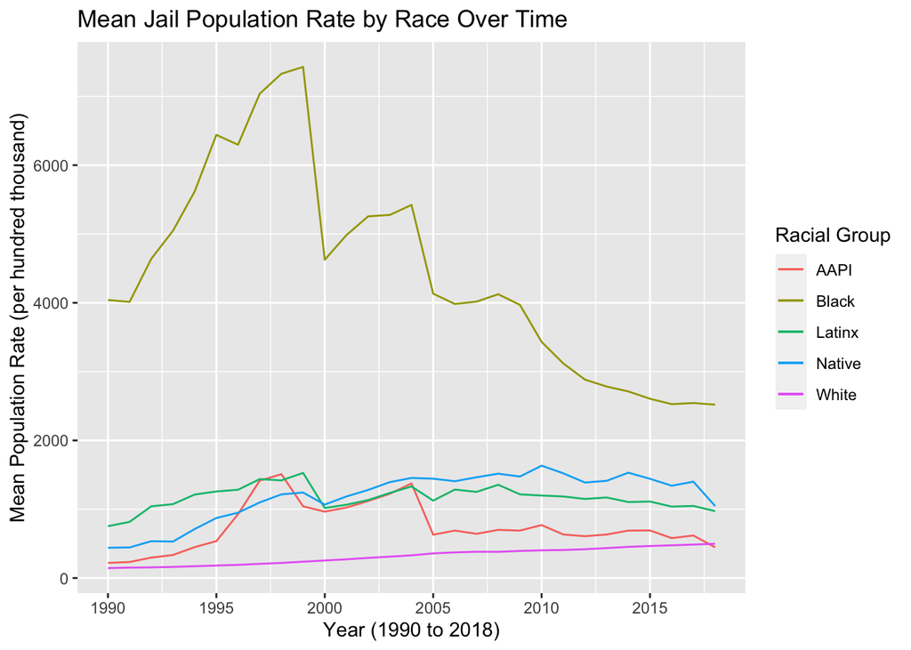

### Variable Comparison Chart

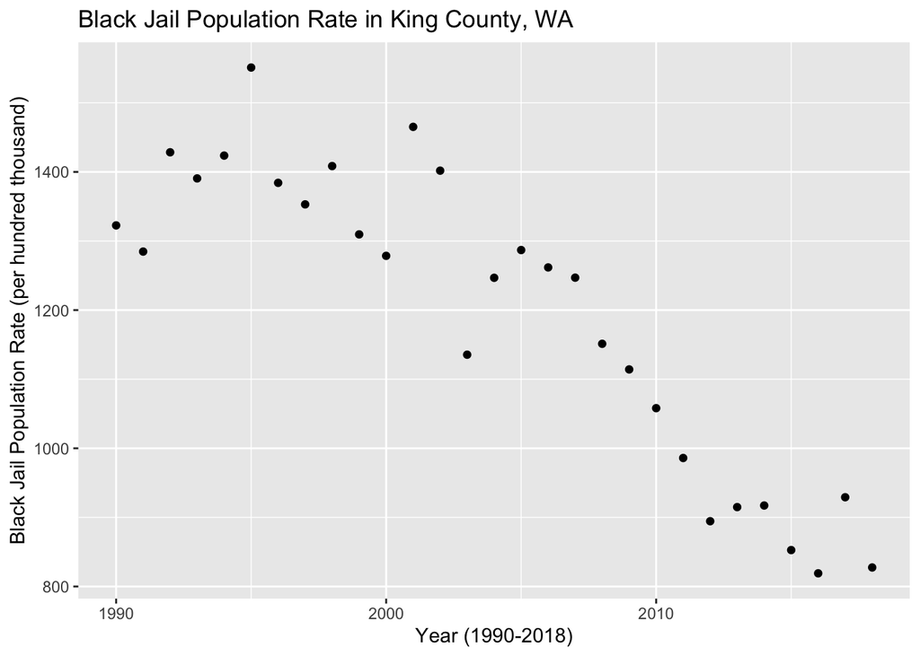

For my second chart, I chose to look at the relationship between time and Black jail population rate by hundred thousand in King County, WA from 1990-2018 (beginning to end of dataset, excluding the years where there was no data). I chose this because King County covers a vast amount of area in WA and has some big cities, so I thought this would be a meaningful relationship to visualize, especially since this is happening right around us. By looking at this chart, I can see that there has been a negative, moderately strong relationship between the years and Black jail rate in King County. As the years go on, the population rate dropped from almost 1,500 to just above 800. I thought that this was an interesting thing to see as I did expect it to have a strong, positive relationship and that population rates have gone up. This was surprising and I think it demonstrates potential progress in racial profiling and racism in the jail system.

### Map

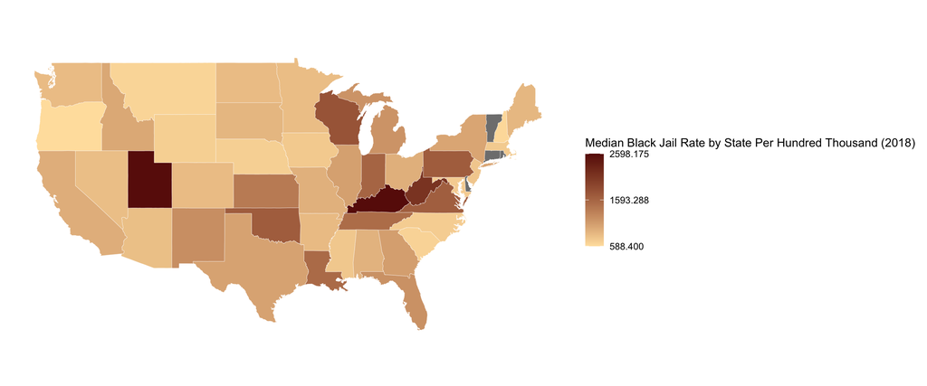

My map shows the variation across states of median jail population rate of Black individuals, pulled specifically from 2018. I chose 2018 because it was the most recent year in the dataset, and I feel that it is most timely as it is closest to 2023. I chose calculating the median of each state to measure the central tendency of Black jail population rates, and I did not choose calculating the mean as the data had more extremes where some counties in certain states had a population of zero, while others had much higher numbers that seemed to be outliers. From my map, I can see that Utah and Kentucky have the highest medians, which means that taking in account all the countries of each state, they overall had a higher Black jail population rate. It also looks like Oregon is one of the lowest, illustrated by its light state color. It does seem that the midwest, South, and East Coast have higher rates, aside from Utah. Seeing this visualization can help generate possibilites for why certain states have higher or lower rates, such as Black population, difference in policies/laws, etc.